# Attendance Time and Intercolony Movements

Author

Eleanor

Here are three potential approaches for calculating attendance time and inter-colony movements. My goal is to use the same dataframe for both of those statistics. I want to 1) include times when birds are in burrows or crevices in attendance time, 2) judiciously include birds that are only being detected on one antenna per receiver, 3) exclude birds that are in between or transiting between Gull and Great Island where possible, and 4) minimize the rapid, vacillating “movements” between Great and Gull Island that likely reflect VHF noisiness instead of inter-colony movements.

## One minute bins, antenna then power priority, one-minute IC movements removed.

This is the most similar to approaches you’ve seen before. Detections are grouped into one-minute bins (one minute = one scan cycle). Each bin is then assigned to an island. The assignment is done first based on the number of antennas pinged (e.g., if a bird pings two Great Island antennas and one Gull Island antenna, it is on Great Island). If the number of antennas pinged is equal (most commonly one antenna each from Great and Gull), then assignment is done based on which receiver recorded the higher average transmission power in that scan cycle. This approach is the most inclusive of one-antenna runs of detections, which means it is also the most inclusive of those short, one-cycle vacillations that look like impossibly brief inter-colony movements.

We exclude three individual bird-minutes (each belonging to a different bird) where both the total power received and the number of antennas represented was equal for Great and Gull Island.

```r
visitors <- prospecting_detections %>%
  filter(nightdate != capture_nightdate) %>%
  group_by(tag_id) %>%
  count() %>%
  dplyr::select(tag_id)

visitors <- as.list(visitors$tag_id) ## Gives a list of every bird that returned at least once

assigned_to_islands <- prospecting_detections %>%
  mutate(bin = binner(datetime, "1 mins")) %>%
  mutate(direction = case_when(bearing == 196 ~ "Gull-south",
                                 bearing == 16 ~ "Gull-north",
                                 bearing == 106 ~ "Gull-east",
                                 bearing == 286 ~ "Gull-west",
                                 bearing == 325 ~ "Great-northwest",
                                 bearing == 235 ~ "Great-southwest",
                                 bearing == 145 ~ "Great-southeast",
                                 bearing == 55 ~ "Great-northeast",
                                 bearing == 343 ~ "Baccalieu-north",
                                 bearing == 73 ~ "Baccalieu-east",
                                 bearing == 163 ~ "Baccalieu-south",
                                 bearing == 253 ~ "Baccalieu-west",
                                 .default = "NA")) %>%
  group_by(tag_id, bin, direction) %>%
  summarize(mean_power = mean(power)) %>%
  mutate(island = case_when(direction %in% c("Gull-south", "Gull-north", "Gull-east", "Gull-west") ~ "Gull",
                            direction %in% c("Great-northwest", "Great-southeast", "Great-southwest", "Great-northeast") ~ "Great",
                            direction %in% c("Baccalieu-north", "Baccalieu-south", "Baccalieu-south", "Baccalieu-north") ~ "Baccalieu")) %>%
  group_by(tag_id, bin, island) %>%
  summarize(n_antennas = length(unique(direction)), mean_power = mean(mean_power)) %>%
  pivot_wider(names_from = "island", values_from = c("n_antennas", "mean_power"), values_fill = 0) %>%
  select(-mean_power_NA, -n_antennas_NA) %>%
  rename(gull_antennas = n_antennas_Gull,
         great_antennas = n_antennas_Great,
         gull_power = mean_power_Gull,
         great_power = mean_power_Great,
         bac_antennas = n_antennas_Baccalieu,
         bac_power = mean_power_Baccalieu) %>%
  mutate(area = if_else(bac_antennas > 0, "Baccalieu", "Witless Bay")) %>%
  mutate(island = case_when(area == "Witless Bay" & gull_antennas > great_antennas ~ "Gull",
                            area == "Witless Bay" & great_antennas > gull_antennas ~ "Great",
                            area == "Witless Bay" & gull_antennas == great_antennas ~ "Both",
                            area == "Baccalieu" ~ "Baccalieu")) %>%
  mutate(island = case_when(island == "Both" & gull_power > great_power ~ "Gull",
                            island == "Both" & gull_power < great_power ~ "Great",
                            island != "Both" ~ island,
                            .default = NA)) %>%
  filter(!is.na(island))
```

The next step uses two nested for loops to group our bird-minutes into segments. The first loop simply iterates by tag ID so that we consider each bird separately. The second loop loops through each island-assigned bird-minute that we created above (dataset arranged chronologically) and assigns it a segment number. The segment number starts at 1 and increases by 1 when either 1) the assigned island changes, or 2) the “night-of” date changes. Therefore each segment ends when the bird either 1) changes island or 2) leaves the area for the night. This should address periods where the bird is in a burrow or crevice, as long as it is detected at least once on the island in question after leaving the burrow or crevice. Each segment can be considered an individual colony “visit”. We can then calculate the length of each segment by subtracting the time of the first bird-minute in each segment (its arrival on that island for that visit) from the last bird-minute in each segment (its last minute present before departure). In this case I am only considering birds which came back to visit the island at least once after being tagged, but it would be simple to include the others (I have excluded them only because it seems likely that their colony attendance behaviour on the night of tagging would be affected by being captured, and the night of capture represents our only data for those birds).

```r
visit_segments_loop <- data.frame() #For the record, this is the line of code that the last version was missing, which means that each time I ran the for loop, I was adding on to the existing dataset of segments instead of making a new, blank dataframe. It made all the colony attendance numbers look super inflated.


for (i in visitors) { #Create iterating segment numbers

groups = list(1)
counter = 1

df <- assigned_to_islands %>%
  filter(tag_id == i) %>%
  mutate(nightdate = nightdater(bin))

  for (n in 2:length(df$tag_id)) {

    if (df$island[n] == df$island[n-1] & as.character(df$nightdate[n]) == as.character(df$nightdate[n-1])) {
      groups <- append(groups,counter)
     # print("same")
     } else {
      counter = counter + 1
      groups <- append(groups,counter)

      #print("dif")
    }

  }

groups <- as.data.frame(groups)

groups <- groups %>%
  pivot_longer(everything())

df <- cbind(df, groups$value) %>%
  dplyr::rename(segment = `...12`)

visit_segments_loop <- rbind(visit_segments_loop, df)
}
```

Now we can calculate segment lengths by subtracting the first detection in each segment from the last. In this case I set all segments that contain a single one-minute bin to be 60 seconds in length.

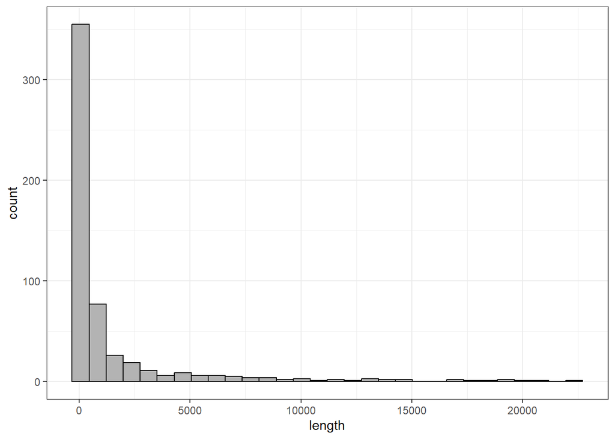

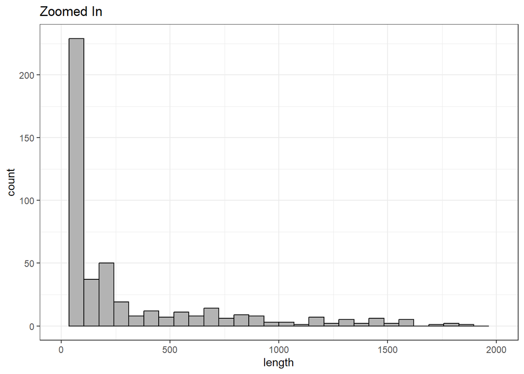

we end up with an overwhelming number of segments that are only 60 seconds in length. Because segments get cut off when either the island or the night-of date changes, many of these very short segments represent those rapid vacillations in island assignment that I don’t believe are true inter-colony movements. If we don’t filter this dataset at all, we end up with:

```r
segment_lengths %>%
  group_by(tag_id) %>%
  summarize(attendance_time_seconds = sum(length)) %>%
  summary(attendance_time_seconds)
```

```
     tag_id      attendance_time_seconds
 Min.   :145.0   Min.   :  2220
 1st Qu.:153.0   1st Qu.: 10860
 Median :178.0   Median : 19680
 Mean   :173.9   Mean   : 32527
 3rd Qu.:187.0   3rd Qu.: 30120
 Max.   :203.0   Max.   :233520
```

A mean attendance time of 542 minutes per bird (min 37, max 3892, sd 808).

And we end up with:

```r
visit_segments_loop %>%
  group_by(tag_id, segment, island, nightdate) %>%
  summarize(segment = mean(segment)) %>%
  transform(last_island = lag(island, n = 1)) %>%
  transform(last_tag = lag(tag_id, n = 1)) %>%
  mutate(ic_move = if_else(tag_id == last_tag & island != last_island, "yes", "no")) %>%
  filter(ic_move == "yes") %>%
  group_by(island, last_island) %>%
  count()
```

```
# A tibble: 6 × 3
# Groups:   island, last_island [6]
  island    last_island     n
  <chr>     <chr>       <int>
1 Baccalieu Great           3
2 Baccalieu Gull            5
3 Great     Baccalieu       1
4 Great     Gull          236
5 Gull      Baccalieu       5
6 Gull      Great         231
```

481 inter-colony movements, 467 of which are between Great and Gull. The similarity of the Great -> Gull count and the Gull -> Great count further makes me suspect that these are rapid, vacillating assignments that don’t reflect real movements.

If we filter out those one-minute bins (which I think we should), we end up with:

```
     tag_id      attendance_time_seconds
 Min.   :145.0   Min.   :  2100
 1st Qu.:153.0   1st Qu.:  9960
 Median :178.0   Median : 18120
 Mean   :173.9   Mean   : 31978
 3rd Qu.:187.0   3rd Qu.: 29580
 Max.   :203.0   Max.   :230880
```

A mean colony attendance time of 532 minutes (min 35 minutes, max 3848 minutes, sd 800 minutes)

And:

```
# A tibble: 6 × 3
# Groups:   island, last_island [6]
  island    last_island     n
  <chr>     <chr>       <int>
1 Baccalieu Great           3
2 Baccalieu Gull            5
3 Great     Baccalieu       1
4 Great     Gull           78
5 Gull      Baccalieu       3
6 Gull      Great          73
```

Our graph of colony attendance time looks like this:

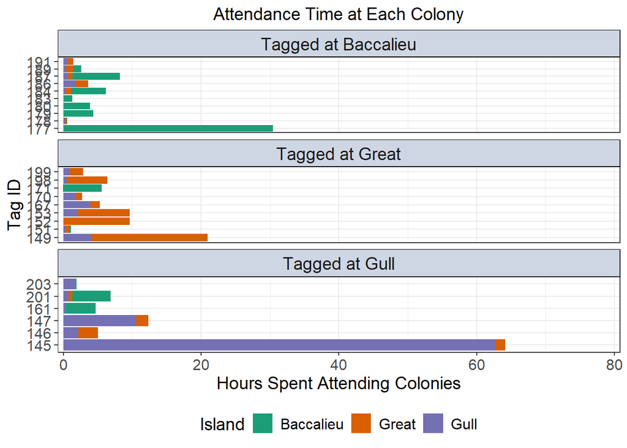

And our map of inter-colony movements looks like this:

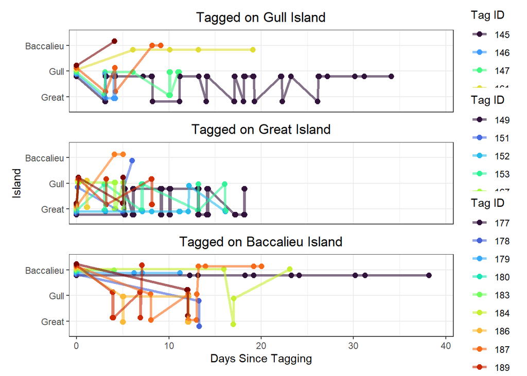

```
# A tibble: 108 × 3
# Groups:   tag_id, nightdate [108]
   tag_id nightdate      n
    <dbl> <date>     <int>
 1    145 2025-06-16     1
 2    145 2025-06-19     5
 3    145 2025-06-20     3
 4    145 2025-06-23     1
 5    145 2025-06-24     3
 6    145 2025-06-27     4
 7    145 2025-06-29     2
 8    145 2025-06-30     3
 9    145 2025-07-03     4
10    145 2025-07-04     3
# ℹ 98 more rows
```

## Approach Two: Only include bins where at least two antennas (on one receiver) are pinged

In this case we will still group detections into one-minute bins, but then we will remove any bins where fewer than two antennas (from at least one island) are pinged in that minute. In this case the segmenter loop will include periods where the bird is detected on only one antenna in attendance time, *as long as it is detected by at least two antennas on that island at least once before leaving*, which is certainly not a given. The same antenna then power priority rules for assignment apply. This should reduce the number of inter-colony movements and the attendance time by removing periods where the bird is between islands and only appearing on one antenna per receiver. I am afraid that this will remove real attendance time, for example, if a bird is sitting on Baccalieu only in range of the north-facing antenna.

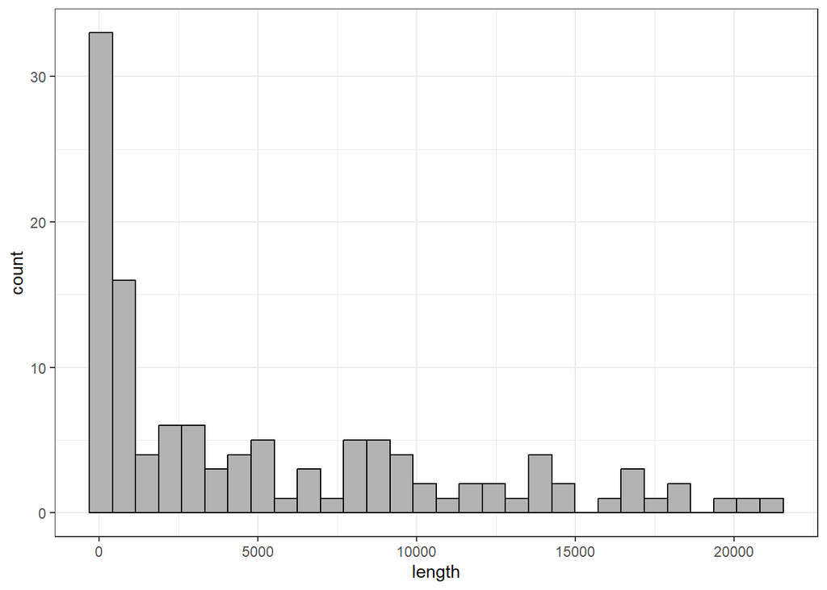

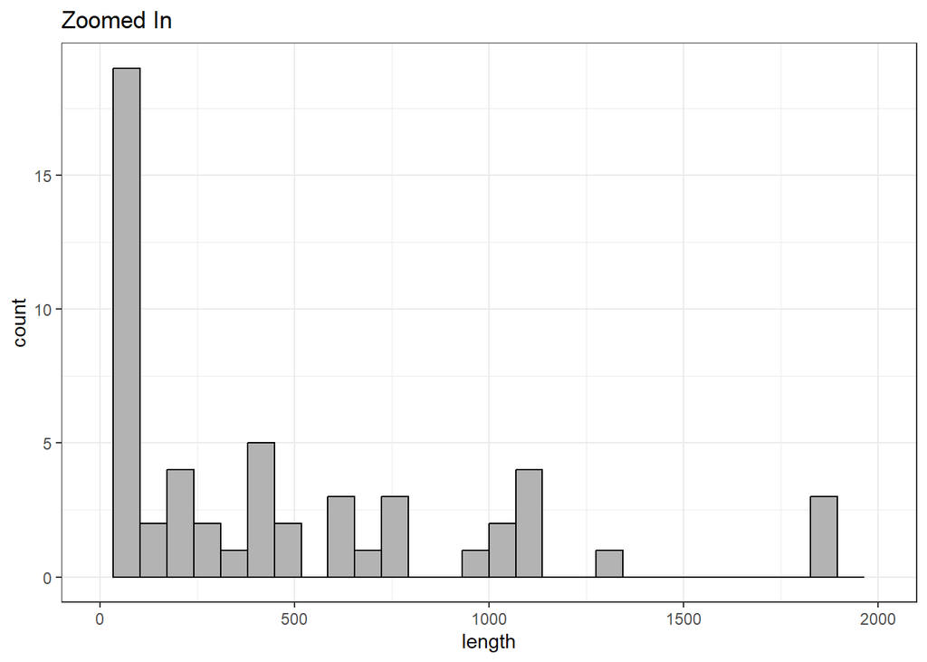

As expected, we end up with fewer segments, but still many that are only one minute in length. In this case I don’t think we need to filter those out, because those are still minutes when at least two antennas detect a bird, so they might just be short fly-overs. But we’ll see how they affect our inter-colony movement count.

We now end up with:

```r
segment_lengths %>%
  group_by(tag_id) %>%
  summarize(attendance_time_seconds = sum(length)) %>%
  mutate(attendance_time_mins = attendance_time_seconds / 60) %>%
  summary(attendance_time_seconds)
```

```
     tag_id      attendance_time_seconds attendance_time_mins
 Min.   :145.0   Min.   :   780          Min.   :  13.0
 1st Qu.:152.5   1st Qu.:  5970          1st Qu.:  99.5
 Median :177.0   Median : 10440          Median : 174.0
 Mean   :172.3   Mean   : 27227          Mean   : 453.8
 3rd Qu.:186.5   3rd Qu.: 22260          3rd Qu.: 371.0
 Max.   :201.0   Max.   :215040          Max.   :3584.0
```

And we end up with:

```r
visit_segments_loop %>%
  group_by(tag_id, segment, island, nightdate) %>%
  summarize(segment = mean(segment)) %>%
  transform(last_island = lag(island, n = 1)) %>%
  transform(last_tag = lag(tag_id, n = 1)) %>%
  mutate(ic_move = if_else(tag_id == last_tag & island != last_island, "yes", "no")) %>%
  filter(ic_move == "yes") %>%
  group_by(island, last_island) %>%
  count()
```

```
# A tibble: 4 × 3
# Groups:   island, last_island [4]
  island    last_island     n
  <chr>     <chr>       <int>
1 Baccalieu Gull            3
2 Great     Gull           26
3 Gull      Baccalieu       1
4 Gull      Great          25
```

55 inter-colony movements, 51 of which are between the Witless Bay Islands. If we filter out the shortest segments:

```
# A tibble: 4 × 3
# Groups:   island, last_island [4]
  island    last_island     n
  <chr>     <chr>       <int>
1 Baccalieu Gull            3
2 Great     Gull           18
3 Gull      Baccalieu       1
4 Gull      Great          16
```

We end up with 38 inter-colony movements, 34 of which are between Great and Gull. This is very conservative, and gives us an average of 1.52 inter-colony movements per bird, which I think is unrealistic.

Our figures look like this:

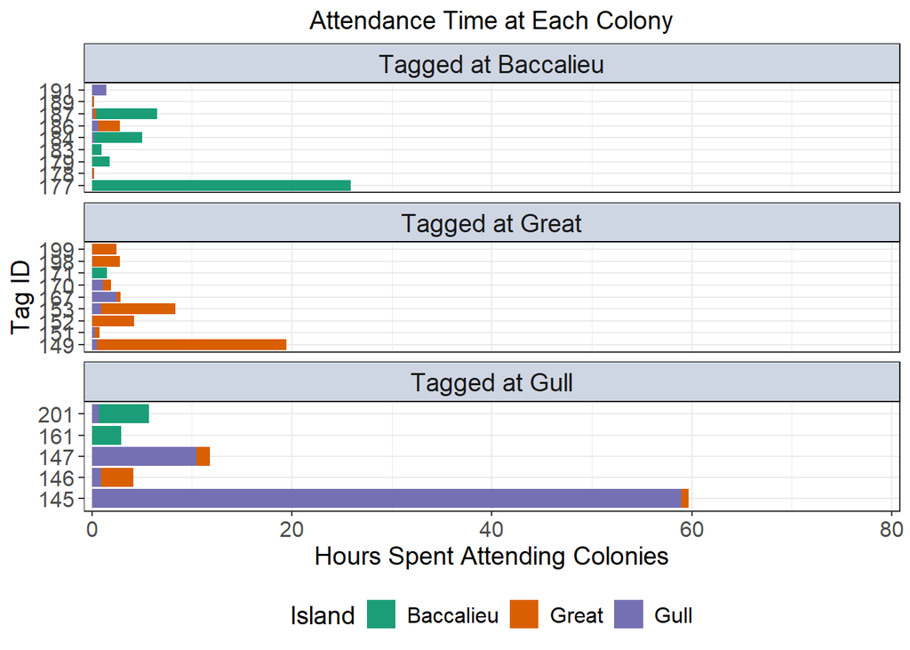

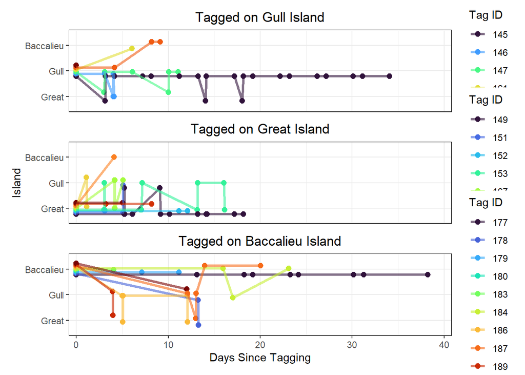

This strict criteria of at least two antennas eats up some of our Baccalieu -> Witless Bay movements. I think this is because Baccalieu birds frequently only show up on one antenna, and I think it’s unfair. If you are a Witless Bay bird and are detected on even one Baccalieu antenna, that should count for something (and this method eats up both of our same-night WB -> Baccalieu movements, which is terrible!). In the colony attendance figure, it’s also clear that this removes a lot of non-home-colony attendance, especially from our Witless Bay birds. We also lose all data from birds 203 and 180, because they never showed up on at least two antennas simultaneously.

We can try another approach with a more complicated island assignment critera to try and get the best of both worlds.

## Approach Three: Island assignment based on two antennas OR frequent appearance on one antenna

You suggested using a criteria that looks at the percentage of possible detections occuring on a single antenna. Because each antenna is scanned for 15 seconds per scan cycle, a bird that is close to the receiver will be detected twice by each antenna in each cycle. One option is to assign birds to the island where one antenna is being pinged IF they ping that antenna, on average, more than once per scan cycle.

In this case, it doesn’t make sense to use one minute bins, because we need more data to determine if a bird is pinging an antenna regularly. However, using larger bins will slightly inflate our attendance time, because it will round all of our segments up to at least the length of that bin. Let’s try with three-minute bins and see if our attendance time looks too inflated.

In this case, I will consider a bird to be on an island if it pings at least two antennas (on that island) OR if it pings one antenna at least four times in three minutes. Antenna number will still be the first priority for breaking ties. But in the case of one-antenna ties, I will here use the number of pings in the three-minute interval as a tiebreaker (and then power if I have to).

This leaves us with 2,570 three-minute bins where a bird was defined as “present” on an island (our strict two-antenna criteria gave us 2252 one-minute bins, so we are reclaiming some time). We loop through the bins normally to split them into segments.

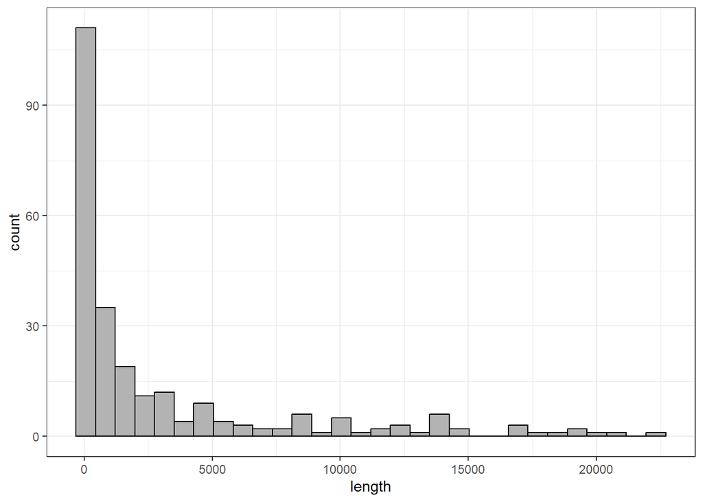

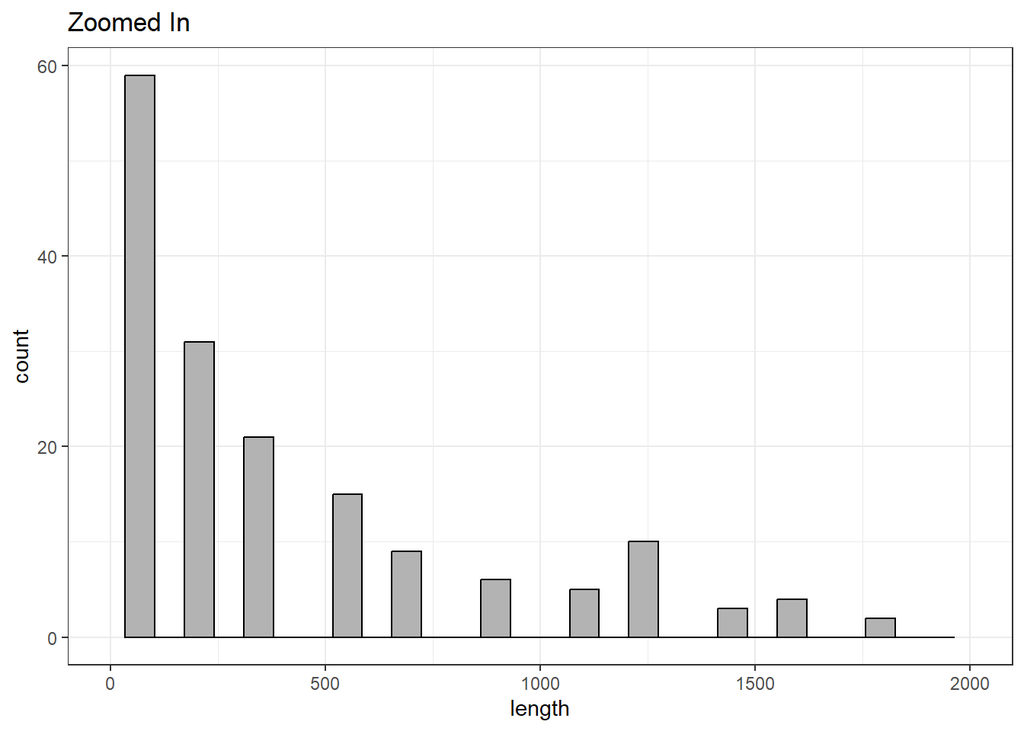

We end up with a lot of three-minute (our new minimum) segments. We may need to filter these out.

```r
segment_lengths %>%
  group_by(tag_id) %>%
  summarize(attendance_time_seconds = sum(length)) %>%
  mutate(attendance_time_mins = attendance_time_seconds / 60) %>%
  #summarize(sd = sd(attendance_time_mins))
  summary(attendance_time_seconds)
```

```
     tag_id      attendance_time_seconds attendance_time_mins
 Min.   :145.0   Min.   :   900          Min.   :  15.0
 1st Qu.:153.0   1st Qu.:  9780          1st Qu.: 163.0
 Median :178.0   Median : 15720          Median : 262.0
 Mean   :173.9   Mean   : 30158          Mean   : 502.6
 3rd Qu.:187.0   3rd Qu.: 22980          3rd Qu.: 383.0
 Max.   :203.0   Max.   :228780          Max.   :3813.0
```

And we end up with:

```r
visit_segments_loop %>%
  group_by(tag_id, segment, island, nightdate) %>%
  summarize(segment = mean(segment)) %>%
  transform(last_island = lag(island, n = 1)) %>%
  transform(last_tag = lag(tag_id, n = 1)) %>%
  mutate(ic_move = if_else(tag_id == last_tag & island != last_island, "yes", "no")) %>%
  filter(ic_move == "yes") %>%
  group_by(island, last_island) %>%
  count()
```

```
# A tibble: 6 × 3
# Groups:   island, last_island [6]
  island    last_island     n
  <chr>     <chr>       <int>
1 Baccalieu Great           2
2 Baccalieu Gull            6
3 Great     Baccalieu       1
4 Great     Gull           79
5 Gull      Baccalieu       5
6 Gull      Great          78
```

171 inter-colony movements, which is 6.84 per bird. 157 of these are in Witless Bay. We are clearly back to counting some “in-between” time as inter-colony movements. Changing our ping-number critera from four in three minutes to five in three minutes takes these numbers down to 133 IC movements, 119 of which are in Witless Bay.

Taking out the shortest segments (3 minutes) here gives us:

```
# A tibble: 6 × 3
# Groups:   island, last_island [6]
  island    last_island     n
  <chr>     <chr>       <int>
1 Baccalieu Great           2
2 Baccalieu Gull            5
3 Great     Baccalieu       1
4 Great     Gull           30
5 Gull      Baccalieu       1
6 Gull      Great          28
```

Our figures look like this:

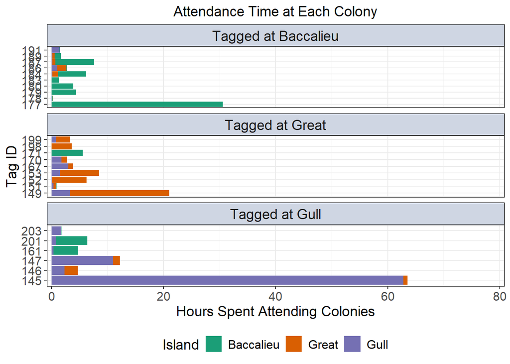

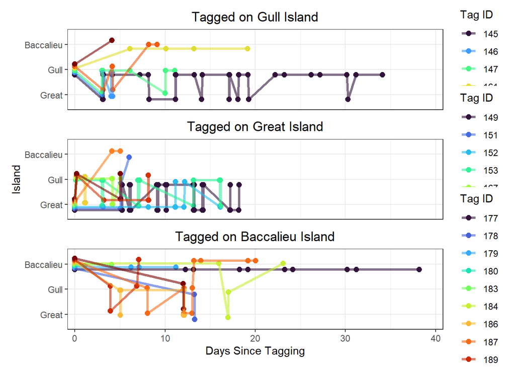

The figures (without the shortest segments filtered out) show about what I expect. I feel like this solution is on the right track in terms of incorporating periods where birds are on one antenna per island. But I’m not super happy with these criteria. Maybe longer bins or requiring more detections per bin would help. But of course, there is never going to be a clear distinction between birds in one-antenna areas and birds making inter-colony movements. There is just a fundamental ambiguity in which Witless Bay Island a bird is on at a time.

My inclination would be to go with either the first approach here (with one-minute segments filtered out) or the third.

We could also simply use a different criteria for Baccalieu, since there’s no issue of overlap, and allow any number of detections to count, there.

We have a dataframe of GPS-referenced VHF detections; we can use the same assignment criteria to see where those points get assigned. We don’t need to run the segmenter for loops, we can just assign them to islands and then map them.

I will group them into three-minute bins; in order to get one position per bin, I’ll just average the lat and lon from all points in that bin. This is probably not kosher.

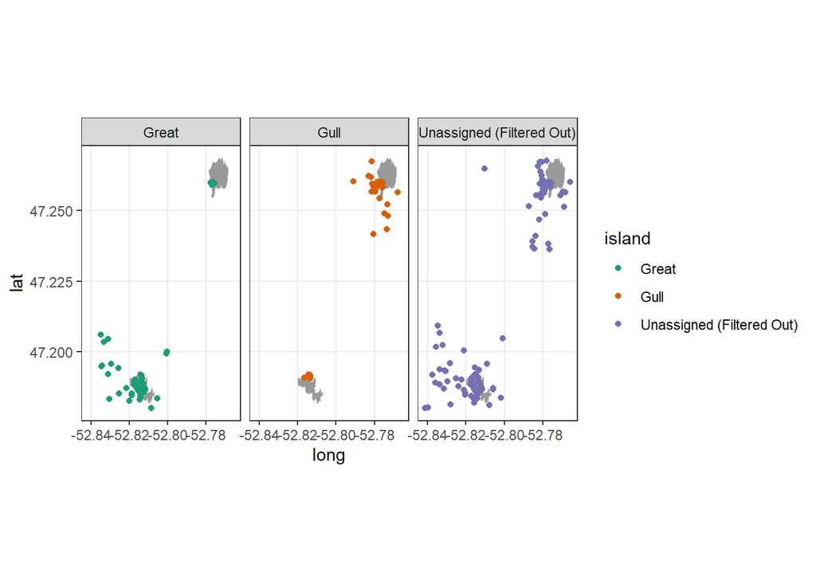

I didn’t send these points through the segmenter loop, but presumably many of these unassigned points would be included in segments.

Our problem areas are exactly where we’d expect. All in all I think this works pretty well and using the two-step criteria is probably acceptable.

## What if we just drop our two problem antennas?

In this case, I will assign birds based on our first critera (antenna then power priority and one-minute bins, but only one antenna required) and just remove the northeast-facing antenna on Great Island and the south-facing antenna on Gull Island from the dataset entirely.

In the case of one-minute bins, adding a qualifier that would use the “back-shadow” of those antennas’ opposite antenna doesn’t make sense–detections on the back-shadow antennas will cause the minute in which they occur to be included in the attendance time anyway. This is also as generous as possible with the Baccalieu detections.

We end up with 4,788 bird-minutes of colony attendance. Without filtering those two antennas, we would have 8,230. So we are losing quite a bit of attendance time, but we’ll see how much of that time gets picked back up by the segmenter loop.

Here is our histogram of segment lengths:

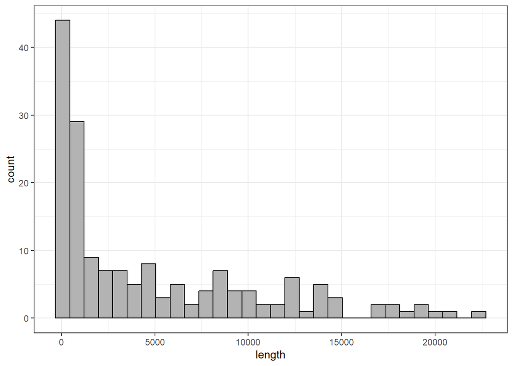

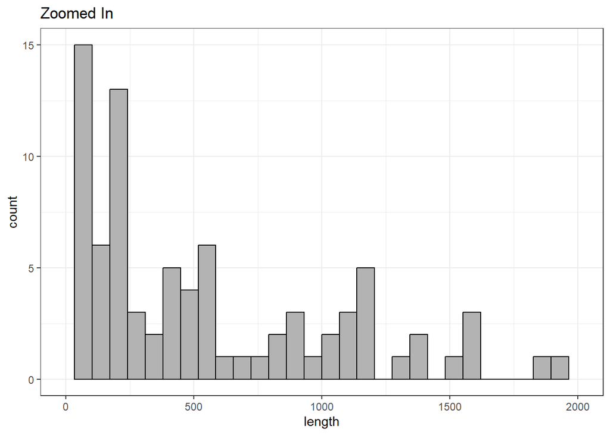

Many, many fewer one-minute segments. We end up with:

```r
segment_lengths %>%
  group_by(tag_id) %>%
  summarize(attendance_time_seconds = sum(length)) %>%
  mutate(attendance_time_mins = attendance_time_seconds / 60) %>%
  summary(attendance_time_seconds)
```

```
     tag_id      attendance_time_seconds attendance_time_mins
 Min.   :145.0   Min.   :  1680          Min.   :  28
 1st Qu.:153.0   1st Qu.: 11040          1st Qu.: 184
 Median :178.0   Median : 19260          Median : 321
 Mean   :173.9   Mean   : 32160          Mean   : 536
 3rd Qu.:187.0   3rd Qu.: 28440          3rd Qu.: 474
 Max.   :203.0   Max.   :219300          Max.   :3655
```

A mean attendance time of 536 minutes per bird (min 28, max 3655, sd 745). These numbers remain quite robust to our different definitions.

And we end up with:

```r
visit_segments_loop %>%
  group_by(tag_id, segment, island, nightdate) %>%
  summarize(segment = mean(segment)) %>%
  transform(last_island = lag(island, n = 1)) %>%
  transform(last_tag = lag(tag_id, n = 1)) %>%
  mutate(ic_move = if_else(tag_id == last_tag & island != last_island, "yes", "no")) %>%
  filter(ic_move == "yes") %>%
  group_by(island, last_island) %>%
  count() %>%
  tt()
```

| island | last_island | n |
| --- | --- | --- |
| Baccalieu | Great | 1 |
| Baccalieu | Gull | 7 |
| Great | Baccalieu | 1 |
| Great | Gull | 38 |
| Gull | Baccalieu | 5 |
| Gull | Great | 36 |

88 inter-colony movements, which is pretty conservative. We retain 14 Baccalieu movements (good!) but we’re down to 74 Witless Bay movements, which averages 2.96 per bird.

Our figures look like this:

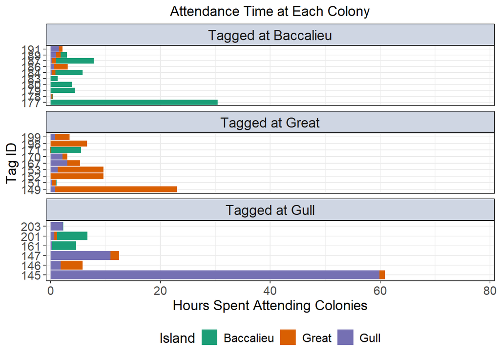

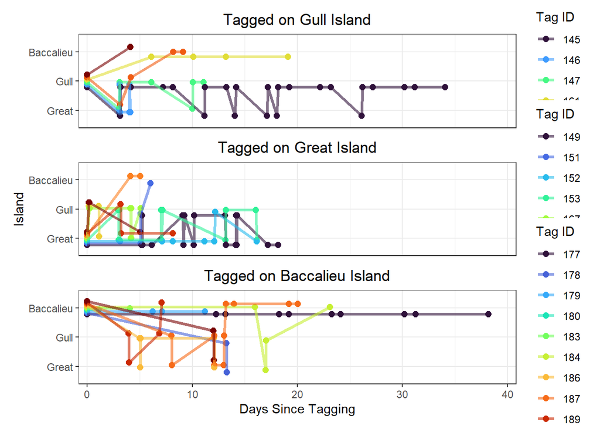

Without dropping our two problem antennas, we have:

| tag_id | n_nights |
| --- | --- |
| 145 | 18 |
| 146 | 3 |
| 147 | 5 |
| 149 | 9 |
| 151 | 3 |
| 152 | 6 |
| 153 | 5 |
| 161 | 5 |
| 167 | 3 |
| 170 | 2 |
| 171 | 3 |
| 177 | 10 |
| 178 | 2 |
| 179 | 4 |
| 180 | 2 |
| 183 | 2 |
| 184 | 4 |
| 186 | 3 |
| 187 | 7 |
| 189 | 3 |
| 191 | 2 |
| 198 | 3 |
| 199 | 2 |
| 201 | 5 |
| 203 | 2 |

113 bird-nights. This is just for our 25 birds that came back at least once after being tagged. A night here counts as any night when they were present at any colony, no matter how many colonies they visited in that night.

And without filtering our problem antennas, we get:

| tag_id | unique_nights_at_Great | unique_nights_at_Gull | unique_nights_at_Baccalieu | total |
| --- | --- | --- | --- | --- |
| 145 | 14 | 18 | 0 | 32 |
| 146 | 3 | 3 | 0 | 6 |
| 147 | 3 | 5 | 0 | 8 |
| 149 | 9 | 8 | 0 | 17 |
| 151 | 2 | 2 | 1 | 5 |
| 152 | 6 | 3 | 0 | 9 |
| 153 | 5 | 4 | 0 | 9 |
| 161 | 0 | 1 | 4 | 5 |
| 167 | 3 | 3 | 0 | 6 |
| 170 | 2 | 2 | 0 | 4 |
| 171 | 1 | 0 | 2 | 3 |
| 177 | 0 | 0 | 10 | 10 |
| 178 | 1 | 1 | 1 | 3 |
| 179 | 0 | 0 | 4 | 4 |
| 180 | 0 | 0 | 2 | 2 |
| 183 | 0 | 0 | 2 | 2 |
| 184 | 1 | 1 | 3 | 5 |
| 186 | 2 | 2 | 1 | 5 |
| 187 | 3 | 3 | 5 | 11 |
| 189 | 2 | 2 | 2 | 6 |
| 191 | 1 | 1 | 1 | 3 |
| 198 | 3 | 3 | 0 | 6 |
| 199 | 2 | 2 | 0 | 4 |
| 201 | 2 | 2 | 2 | 6 |
| 203 | 1 | 1 | 1 | 3 |

This is the count of unique nights where the bird was present (at least once) at a given island, no matter how many times it left and came back in that night. Across our 25 birds, we have 174 island-bird-nights.

If we filter out our problem antennas:

| tag_id | n_nights |
| --- | --- |
| 145 | 18 |
| 146 | 3 |
| 147 | 5 |
| 149 | 9 |
| 151 | 3 |
| 152 | 6 |
| 153 | 5 |
| 161 | 5 |
| 167 | 3 |
| 170 | 2 |
| 171 | 3 |
| 177 | 10 |
| 178 | 2 |
| 179 | 4 |
| 180 | 2 |
| 183 | 2 |
| 184 | 4 |
| 186 | 3 |
| 187 | 7 |
| 189 | 3 |
| 191 | 2 |
| 198 | 3 |
| 199 | 2 |
| 201 | 5 |
| 203 | 2 |

We keep all 113 of our unique bird-nights. So no bird was ever detected on *only* one of our problem antennas in a given night. This isn’t a big surprise, since it’s hard to imagine how they would enter or leave Witless Bay without pinging a different antenna.

For unique island-bird-nights:

| tag_id | unique_nights_at_Great | unique_nights_at_Gull | unique_nights_at_Baccalieu | total |
| --- | --- | --- | --- | --- |
| 145 | 6 | 18 | 0 | 24 |
| 146 | 2 | 3 | 0 | 5 |
| 147 | 2 | 5 | 0 | 7 |
| 149 | 9 | 5 | 0 | 14 |
| 151 | 2 | 1 | 1 | 4 |
| 152 | 6 | 1 | 0 | 7 |
| 153 | 5 | 4 | 0 | 9 |
| 161 | 0 | 1 | 4 | 5 |
| 167 | 2 | 3 | 0 | 5 |
| 170 | 2 | 2 | 0 | 4 |
| 171 | 1 | 0 | 2 | 3 |
| 177 | 0 | 0 | 10 | 10 |
| 178 | 1 | 1 | 1 | 3 |
| 179 | 0 | 0 | 4 | 4 |
| 180 | 0 | 0 | 2 | 2 |
| 183 | 0 | 0 | 2 | 2 |
| 184 | 1 | 1 | 3 | 5 |
| 186 | 2 | 2 | 1 | 5 |
| 187 | 3 | 3 | 5 | 11 |
| 189 | 1 | 2 | 2 | 5 |
| 191 | 1 | 1 | 1 | 3 |
| 198 | 3 | 1 | 0 | 4 |
| 199 | 2 | 1 | 0 | 3 |
| 201 | 1 | 2 | 2 | 5 |
| 203 | 0 | 1 | 1 | 2 |

We are down to 151. So we lose 23 instances of a bird being detected at an “extra” island in a given night. This makes sense alongside our loss of inter-colony movements. These cases would include birds that pinged multiple Great Island antennas in a night, but only pinged the south-facing antenna on Gull in that night. Or where a bird was detected on multiple Gull Island antennas, but only ever pinged Great Island’s problem antenna in that night (for example, this appears to have happened 8 times for bird #145.)

If we look at how many islands each bird visited at least once in their whole season:

| tag_id | islands | n_islands_visited |
| --- | --- | --- |
| 145 | c("Gull", "Great") | 2 |
| 146 | c("Gull", "Great") | 2 |
| 147 | c("Gull", "Great") | 2 |
| 149 | c("Great", "Gull") | 2 |
| 151 | c("Great", "Gull", "Baccalieu") | 3 |
| 152 | c("Great", "Gull") | 2 |
| 153 | c("Great", "Gull") | 2 |
| 161 | c("Gull", "Baccalieu") | 2 |
| 167 | c("Great", "Gull") | 2 |
| 170 | c("Great", "Gull") | 2 |
| 171 | c("Great", "Baccalieu") | 2 |
| 177 | Baccalieu | 1 |
| 178 | c("Baccalieu", "Gull", "Great") | 3 |
| 179 | Baccalieu | 1 |
| 180 | Baccalieu | 1 |
| 183 | Baccalieu | 1 |
| 184 | c("Baccalieu", "Great", "Gull") | 3 |
| 186 | c("Baccalieu", "Gull", "Great") | 3 |
| 187 | c("Baccalieu", "Gull", "Great") | 3 |
| 189 | c("Baccalieu", "Gull", "Great") | 3 |
| 191 | c("Baccalieu", "Gull", "Great") | 3 |
| 198 | c("Great", "Gull") | 2 |
| 199 | c("Gull", "Great") | 2 |
| 201 | c("Gull", "Great", "Baccalieu") | 3 |
| 203 | c("Gull", "Great", "Baccalieu") | 3 |

Our unfiltered dataset gives us 55 total unique bird-islands. So 145 visited both Great and Gull *at least once ever*, while 179 only ever visited Baccalieu. (On average, each of our birds visited 2.2 islands!)

Without the problem antennas, we have:

| tag_id | islands | n_islands_visited |
| --- | --- | --- |
| 145 | c("Gull", "Great") | 2 |
| 146 | c("Gull", "Great") | 2 |
| 147 | c("Gull", "Great") | 2 |
| 149 | c("Great", "Gull") | 2 |
| 151 | c("Great", "Gull", "Baccalieu") | 3 |
| 152 | c("Great", "Gull") | 2 |
| 153 | c("Great", "Gull") | 2 |
| 161 | c("Gull", "Baccalieu") | 2 |
| 167 | c("Great", "Gull") | 2 |
| 170 | c("Great", "Gull") | 2 |
| 171 | c("Great", "Baccalieu") | 2 |
| 177 | Baccalieu | 1 |
| 178 | c("Baccalieu", "Gull", "Great") | 3 |
| 179 | Baccalieu | 1 |
| 180 | Baccalieu | 1 |
| 183 | Baccalieu | 1 |
| 184 | c("Baccalieu", "Great", "Gull") | 3 |
| 186 | c("Baccalieu", "Gull", "Great") | 3 |
| 187 | c("Baccalieu", "Gull", "Great") | 3 |
| 189 | c("Baccalieu", "Gull", "Great") | 3 |
| 191 | c("Baccalieu", "Gull", "Great") | 3 |
| 198 | c("Great", "Gull") | 2 |
| 199 | c("Gull", "Great") | 2 |
| 201 | c("Gull", "Great", "Baccalieu") | 3 |
| 203 | c("Gull", "Baccalieu") | 2 |

54 unique bird-islands. So we lose a single case where a bird (it was #203) was *only ever* detected on Great Island’s problem antenna, and dropping that antenna drops Great Island altogether from its list of islands visited. That Great Island hit was on the night it was tagged, anyway, and very brief, so I think this is a totally fair loss (plus the bird was obviously never actually on Great Island, because it was only in the area at all for a couple of minutes after being tagged).

I’m a little grumpy about how well this works, because I hate to drop so much data, but it suggests that what we know about the antenna ranges is accurate. Removing our problem antennas gives us almost exactly the same mean colony attendance time per bird as our most generous approach (one minute bins without the shortest segments filtered out), removes the need to filter the shortest segments, and cleans up our inter-colony movements to what I think is a reasonable count. We also won’t have to explain a multi-step criteria in the methods and this method is as generous as possible to Baccalieu. I am surprised by how little dropping those antennas affects colony attendance, but I guess birds frequently ping multiple antennas as they arrive or leave, since they probably cross open areas, and arrival/departure is all that really matters for the segmenter loop.